# Régression non-paramétrique

Philippe Real

19/09/2019

```r
#for manipulate data (transform to dataframe)
install.packages("tidyverse")
install.packages("tibble")
install.packages("sm")

install.packages("KernSmooth")
install.packages("np")
install.packages("stats")
install.packages("ggplot2")
```

## 1. Etude de la densitée g des X

### 1.0 Lecture des données et premières analyses

```r
d1 = read.csv("Data1.csv")
summary(d1)
```

```
##       X.1               X                  Y1
##  Min.   :   1.0   Min.   :0.000005   Min.   :-0.2244
##  1st Qu.: 500.8   1st Qu.:0.258074   1st Qu.: 0.2619
##  Median :1000.5   Median :1.192414   Median : 0.4303
##  Mean   :1000.5   Mean   :2.029447   Mean   : 0.5112
##  3rd Qu.:1500.2   3rd Qu.:3.318174   3rd Qu.: 0.6735
##  Max.   :2000.0   Max.   :9.308684   Max.   : 3.1263
```

Pour avoir une idée de la densité de X on peut tracer son histogramme.

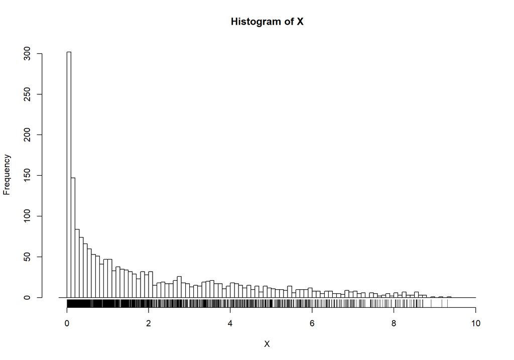

### 1.1 Estimateur non-paramétrique de g(x)

On peut utiliser la fonction bkde du package KernSmooth qui estime la densité par la méthode des noyaux. On prend comme noyau le noyau normal. Ce choix peut sembler arbitraire, mais on a vu que ce n’est pas le choix du noyau qui est le plus important dans l’estimation de la densité. On calcul cette estimateur de la densité pour différentes largeur de fenêtre: h (bandwidth) Et on va déterminer de manière empirique une valeur de h qui semble adapté.

#### Petites valeurs de la fenêtre h: 0.01 / 0.03 / 0.05

| bandwidth h | error quadratic | R2 | Biais | MAE | RMSE |
| --- | --- | --- | --- | --- | --- |
| 0.01 | 8.4851915 | -0.7836155 | -1.9231488 | 1.9540129 | 2.9129352 |
| 0.03 | 8.4818664 | -0.7829165 | -1.92493 | 1.9555547 | 2.9123644 |
| 0.05 | 8.4958757 | -0.7858613 | -1.9266524 | 1.9587723 | 2.9147686 |

[figure not shown]

On remarque de fortes oscilations pour des h entre 0.01 et 0.05.

#### Estimateurs pour h variant de 0.08 à 1

| bandwidth h | error quadratic | R2 | Biais | MAE | RMSE |
| --- | --- | --- | --- | --- | --- |
| 0.08 | 8.4973667 | -0.7861747 | -1.9291322 | 1.9589151 | 2.9150243 |
| 0.20 | 8.5346547 | -0.7940128 | -1.9379603 | 1.9654464 | 2.9214131 |
| 0.40 | 8.5686374 | -0.8011561 | -1.9496624 | 1.9715207 | 2.9272235 |
| 0.70 | 8.6026503 | -0.8083057 | -1.9625062 | 1.9786641 | 2.9330275 |
| 1 | 8.6378039 | -0.8156951 | -1.9717881 | 1.9849216 | 2.9390141 |

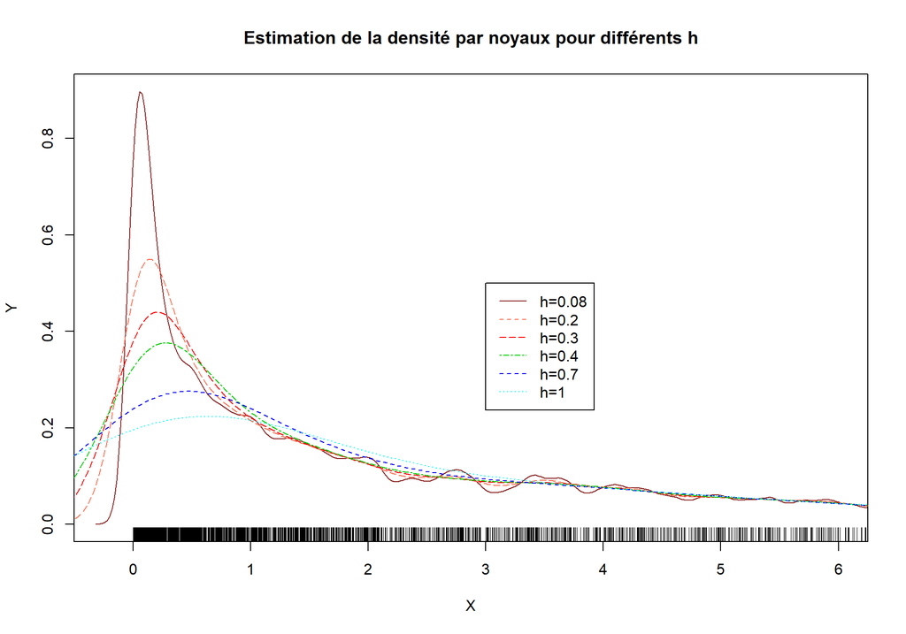

A partir de h = 0.2 l’approximation est plus régulière.

#### Raison pour laquelle ce choix est important et ce qui se produit si h est mal choisi

- Si h est trop grand (courbes bleues) noyau trop régularisant : trop de biais
- Si h est trop petit (courbes marron du graphique ci-dessus) : trop oscillant, trop de variance.

#### Raffinement pour h entre 0.025 et 0.035

| bandwidth h | error quadratic | R2 | Biais | MAE | RMSE |
| --- | --- | --- | --- | --- | --- |
| 0.01 | 8.4851915 | -0.7836155 | -1.9231488 | 1.9540129 | 2.9129352 |
| 0.025 | 8.4811236 | -0.7827604 | -1.9244903 | 1.9541078 | 2.9122369 |
| 0.027 | 8.4810626 | -0.7827475 | -1.9246666 | 1.9546911 | 2.9122264 |
| 0.03 | 8.4818664 | -0.7829165 | -1.92493 | 1.9555547 | 2.9123644 |
| 0.033 | 8.4836088 | -0.7832828 | -1.925192 | 1.9564214 | 2.9126635 |
| 0.035 | 8.4850721 | -0.7835904 | -1.925366 | 1.9569291 | 2.9129147 |

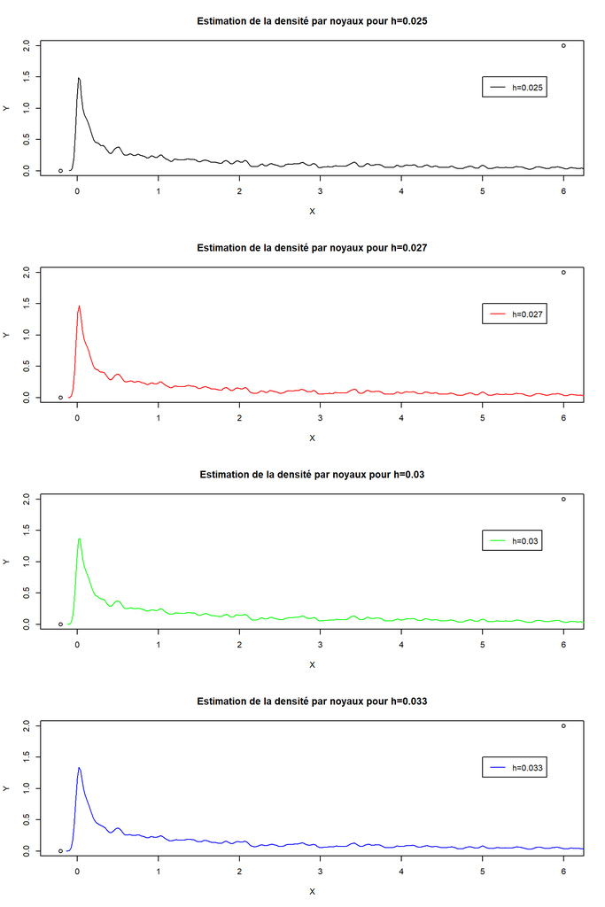

### 1.2 Détermination d’un h optimal

Représentation graphique de l’estimation par noyau de la densité ed X: g(x), où h.n est la fenêtre donnee par validation croisee ou par une autre methode que l’on precisera.

#### 1.2.1 Validation croisée pour la densité,

##### Utilisation de la fonction bw.ucv library stats

```r
  h_ucv<-bw.ucv(X)
  h_ucv
```

```
## [1] 0.05675136
```

#### 1.2.2 Règle Silverman

En appliquant la règle de Siverman, on obtient le h suivant:

```r
n<-length(X)
h_sil<-1.06*sqrt(var(X))*n**(-1/5)
h_sil
```

```
## [1] 0.505695
```

On obtient le même résultat avec la fonction: bw.nrd

##### Fonction bw.nrd

```r
  h_nrd <- bw.nrd(x = X)
  h_nrd
```

```
## [1] 0.505695
```

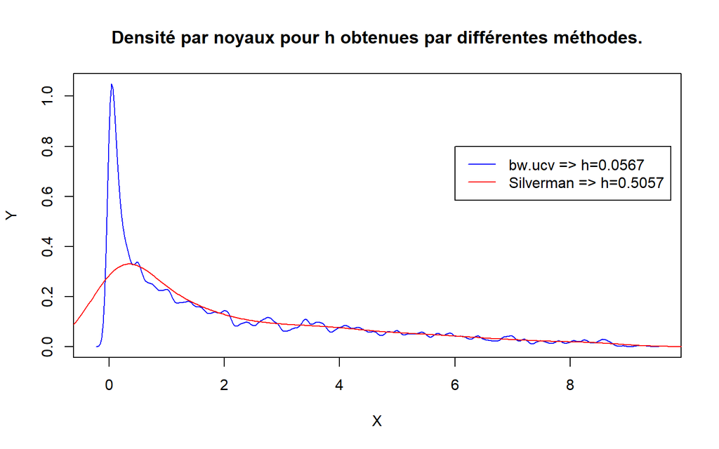

#### 1.2.3 Méthodes alternatives

##### Fonction density

On peut regrarder le résultat de la fonction density du package RSmooth qui teste différents noyaux et renvoie un h optimal

```
## [1] 0.4293637
```

Remarque: La fonction density calcul automatiquement le h optimal. On peut regarder les différentes estimations de la densité issues de noyaux différents. Comme ennoncé plus haut les estimations sont proches (excepté pour le noyau rectangulaire)

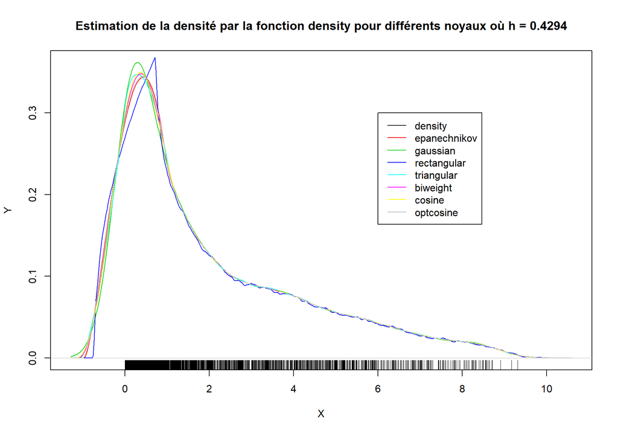

##### Fonction dpik

méthode du package Kersmooth: Select a Bandwidth for Kernel Density Estimation

```
## [1] 0.1439489
```

##### Fonction ucv

La fenêtre h est obtenu par (UCV) de Least Squares Cross-Validation curve (LSCV) et h obtenu (UCV)

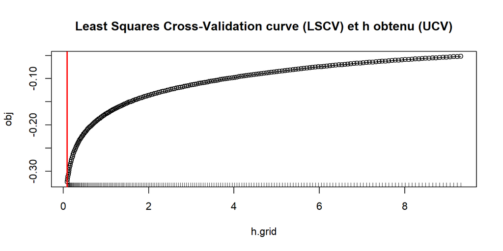

```
## [1] 0.09308678
```

#### Résumé des résultats

| Méthode | valeur de h |
| --- | --- |
| bw.ucv | 0.0567514 |
| dpik | 0.1439489 |
| density | 0.4294 |
| ESM | autour de 0.027 |
| Regle Silverman | 0.505695 |

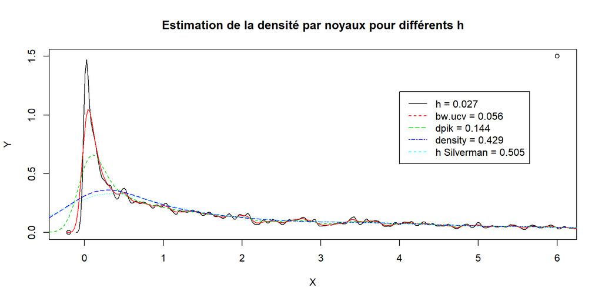

### 1.3 QQPlot - g(x) densité Uniforme ?

Implementation d’un QQ-plot pour vérifier empiriquement l’hypothese g(x) suit (ou pas) une densité Uniforme U=1/10 sur [0,10]

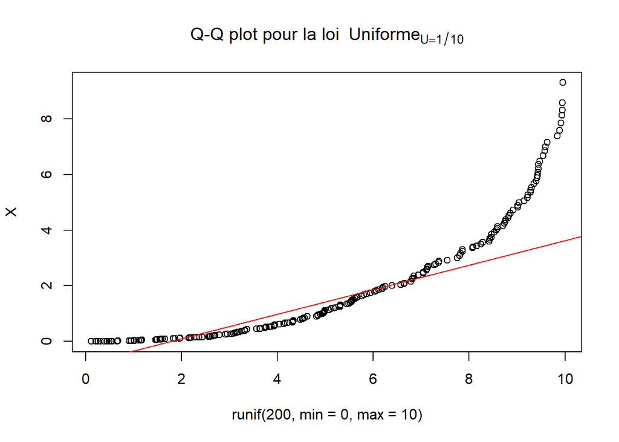

A la vue du graphique QQPlot par rapport à la loi uniforme (U=1/10) l’hypothèse selon laquelle g est uniforme n’est pas raisonnable. Cependant entre les valeurs en abscisse [2,6] l’hypothèse semble plus crédible. On pourrait diviser l’espace en 3 parties: [0 , 2] [2 , 6] [6 , 10]

### 1.4 Zone de l’espace où l’estimation de r sera plus précise

Plus de précision où les données ne sont pas trop dispersées et ou la densité est importante. Donc plus de précision dans l’intervalle [0+dela , 5] La précision diminue à droite… Dans un voisinage de 0 l’estimation n’est pas précise non plus: difficulté d’estimer où g(x) = 0

## 2. Reconstruction de r(x)

On est dans le cadre de l’estimation non paramétrique, on reprend les hypothèses classiques On utilise les données de Data1, (X,Y)

### 2.1 La fonction r peut elle être linéaire ?

On trace Y1 en fonction de X Sans transformation, à la vue du graphe, r ne peut être linéaire.

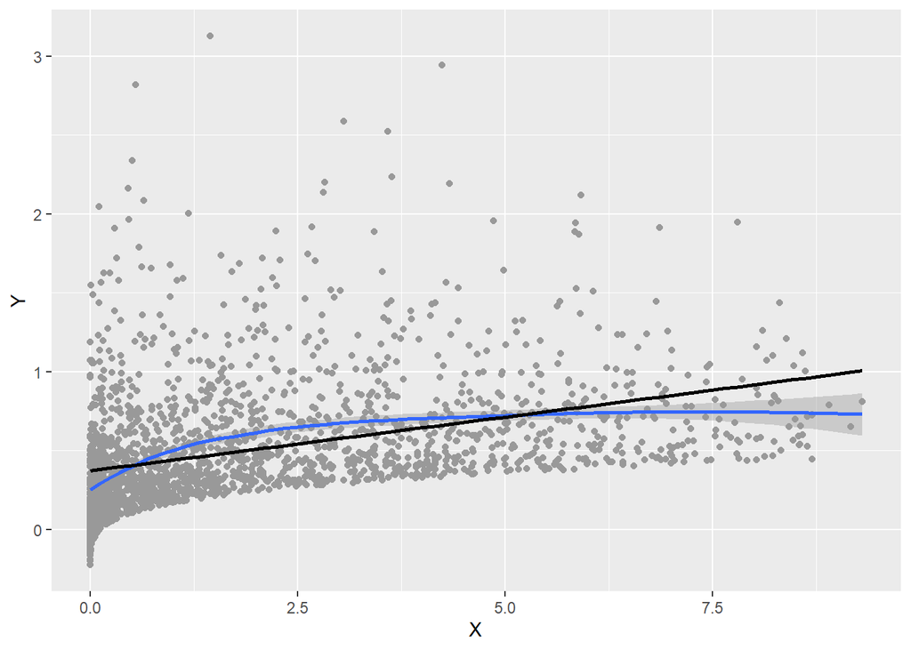

Maintenant On trace Y1 en fonction de log(X)

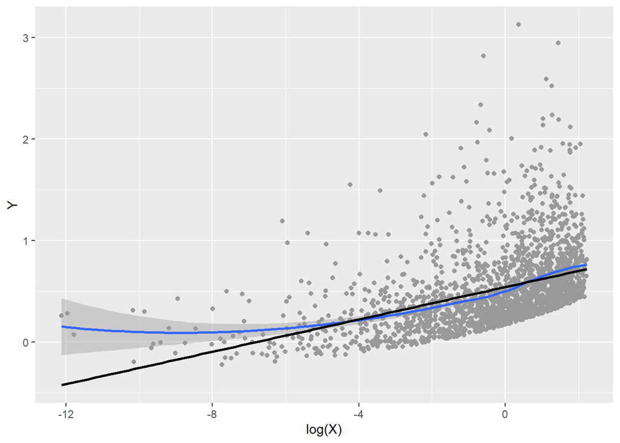

Dans la région [-5,1] où l’on retouve la quasi totalité de l’échantillon, la transfoarmtion (log(x)) a permis de bien linéariser.

### 2.2. Construction d’un estimateur non-parametrique de r(x)

#### Détermination de la fenêtre h

##### Find optimum CV bandwidth, with sensible grid

On trouve un h optimum h = 0.1200601

- Test: choix de $h$ local

```
##     Min.  1st Qu.   Median     Mean  3rd Qu.     Max.
## 0.005019 0.014504 0.036759 0.059364 0.078701 0.173141
```

- Test: choix de hglobal, à l’aide de la fonction dpill

```
## [1] 0.2186849
```

#### Estimateur de Nadaraya-Watson : avec un h_local

h_local calculé aux différents points de grid.

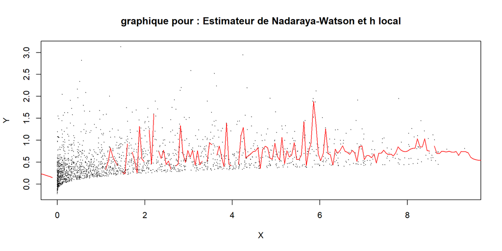

#### Estimateur de Nadaraya-Watson avec la librairie stat - fonction : ksmooth - h = 0.2186849 et h = 0.1200601

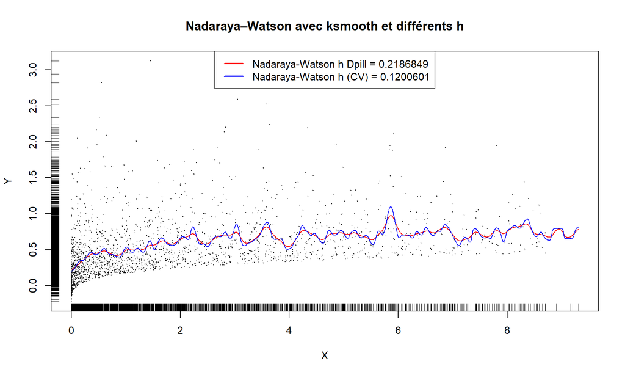

L’estimateur est sensible au choix de h. L’estimateur de Nadaraya-Watson est très oscillant par construction.

#### Estimateur de Nadaraya-Watson à partir de la fonction recodé NW - h = 0.2186849 et h = 0.1200601

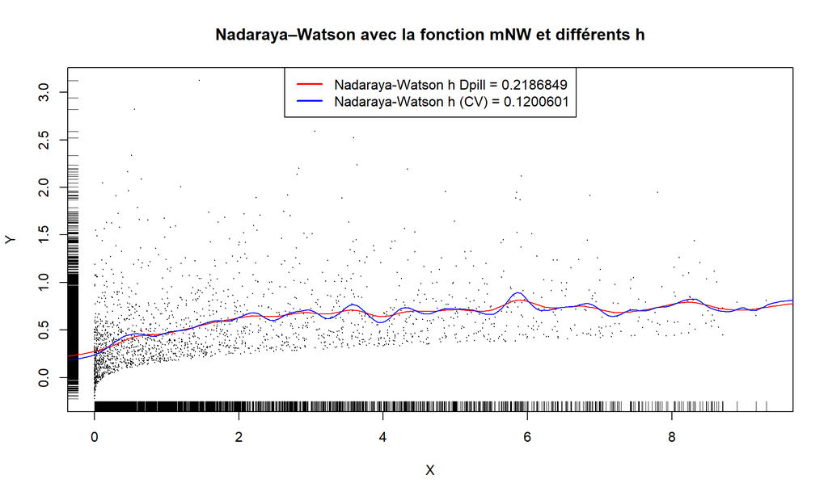

#### Estimateur par polynômes locaux

Utilisation de la fonction locpoly du package Kersmooth avec h = 0.2186849 Attention à ordonner l’échantilon (en X) pour garder la cohérence des couples (X,Y), car sinon KernSmooth va réordonner les X sans tenir compte de la composante Y.

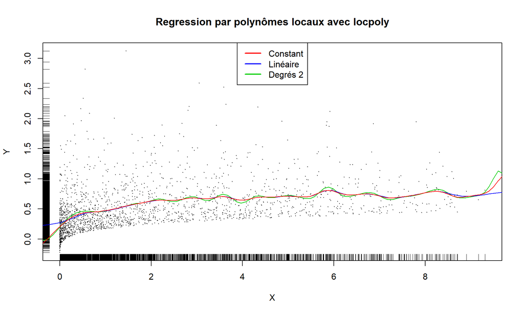

#### Comparaison des différentes méthodes

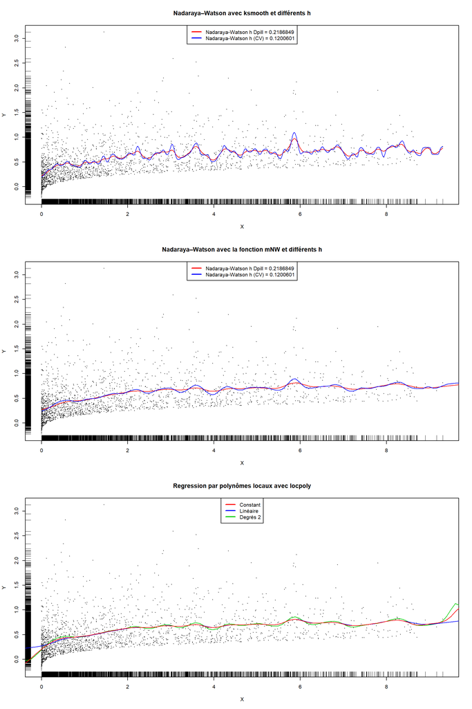

### 2.3. estimation de r en regressant Y1 sur log(X)

```
## [1] 0.649558
```

#### Find optimum CV bandwidth, with sensible grid

#### Estimation de la régression de Log(X) avec Nadaraya-Watson avec la librairie stat - fonction : ksmooth - h = 0.649558 et h = 0.4046381

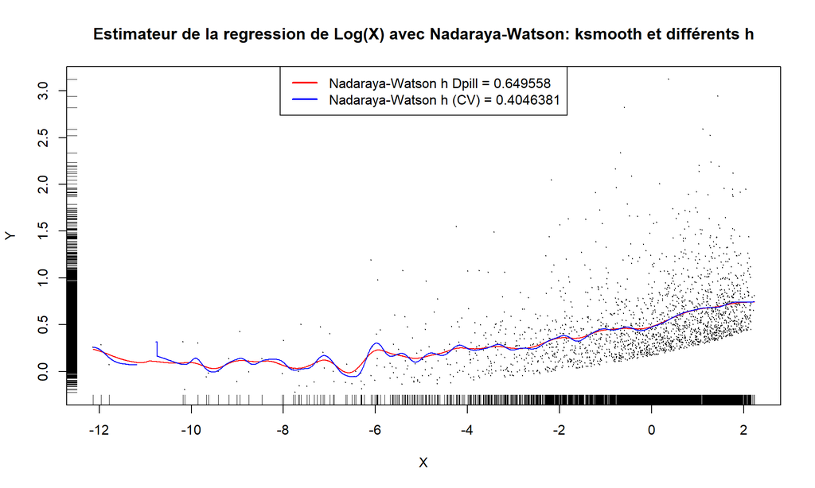

#### Estimateur de la régression de Log(X) avec Nadaraya-Watson à partir de la fonction recodé NW - h = 0.649558 et h = 0.4046381

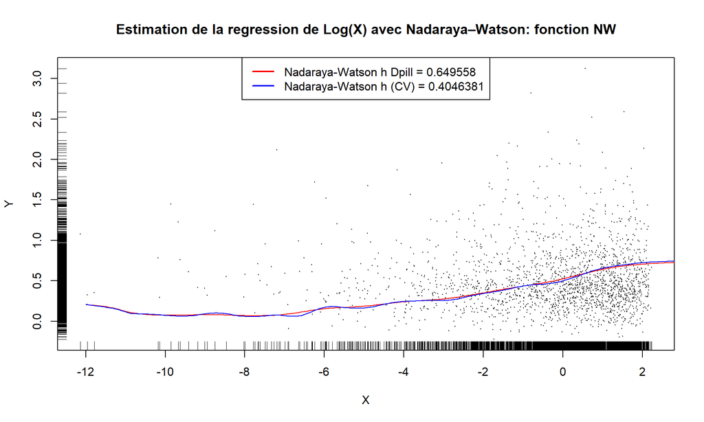

#### Estimation de la régression de Log(X) avec par polynômes locaux

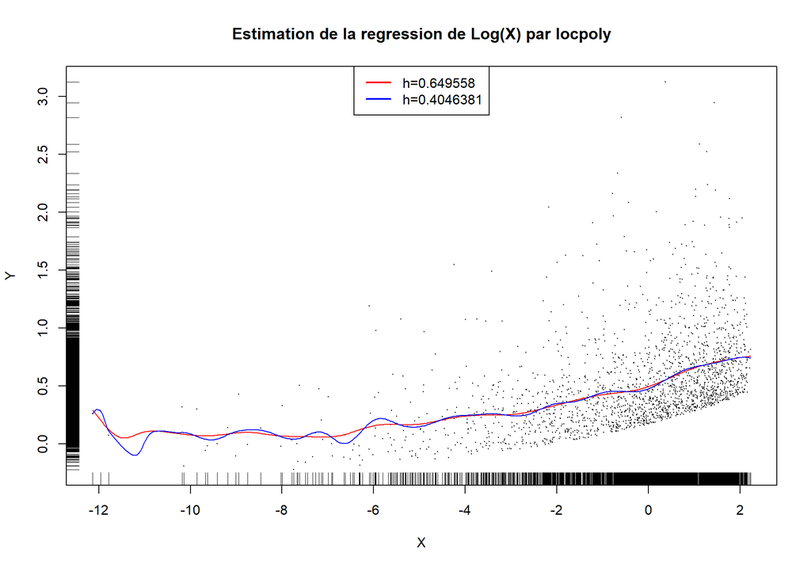

Dans la zone à forte densité où est concentrée l’essentiel de l’information [-5,1] les 2 estimateurs sont très proches, quasiment confondus.

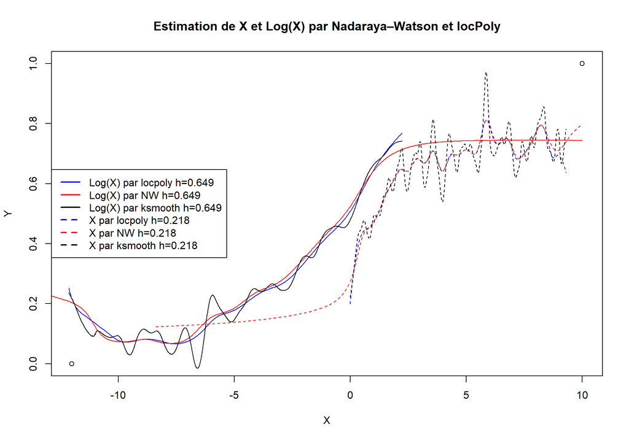

### 2.4. Remarques? Explications?

Régularité proportionalité?

## 3. Etude de la densitée $\mu$(x) des $\xi$i

### 3.1 A partir du jeu de donnees Data1

#### 3.1.1.

La distribution approximative de ~$\xi$i est celle de $\xi$i

#### 3.1.2 Représentation de la densité $\mu$(x) des $\xi$i

choix de h établi a la question 2.2: h=0.2186849

```
## [1] 0.004196189
```

```
## [1] 0.03026436
```

```r
h_ucv
```

```
## [1] 0.004196189
```

```r
h_sil
```

```
## [1] 0.03026436
```

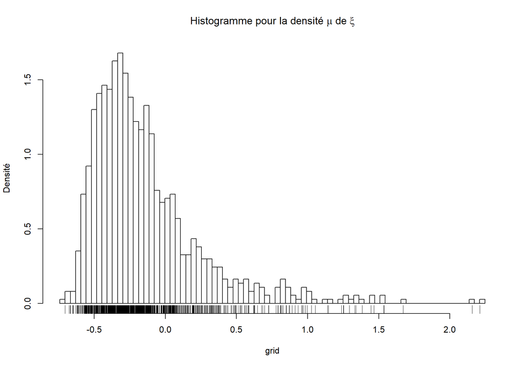

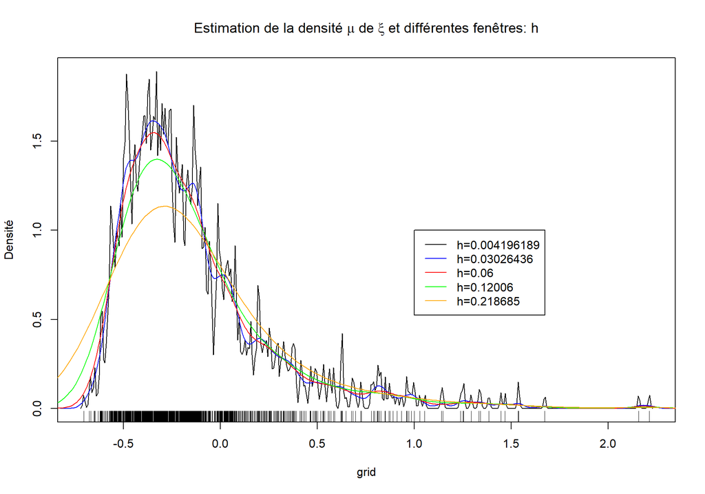

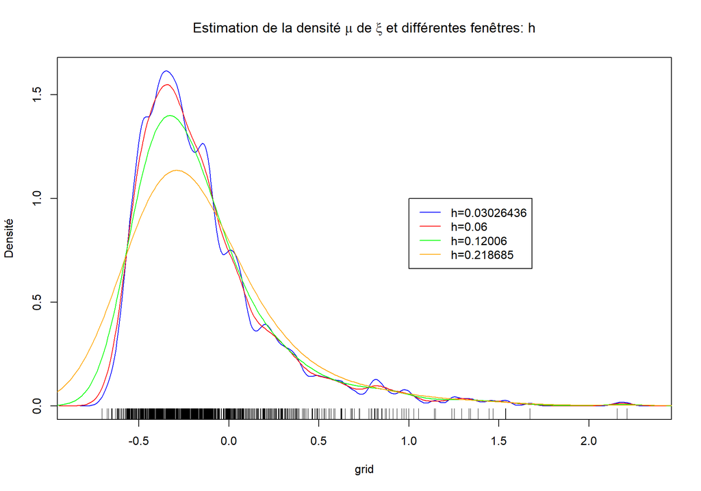

On retrouve la forme du graphe de la densité d’une loi gamma

#### 3.1.3. (Facultatif.) Quel est l’interêt d’avoir decoupé le jeu de donnees selon J+ et J- ?

Pas de fonction “predict” On programme la fonction qui définit l’estimateur.

```
## [1] 0.3622163
```

```
## [1] 0.3622163
```

#### 3.1.4. La densitée $\mu$ peut-elle être gaussienne ?

Protocole empirique de verification http://www.biostat.ulg.ac.be/pages/Site_r/Normalite.html

- 1. test du QQPlot

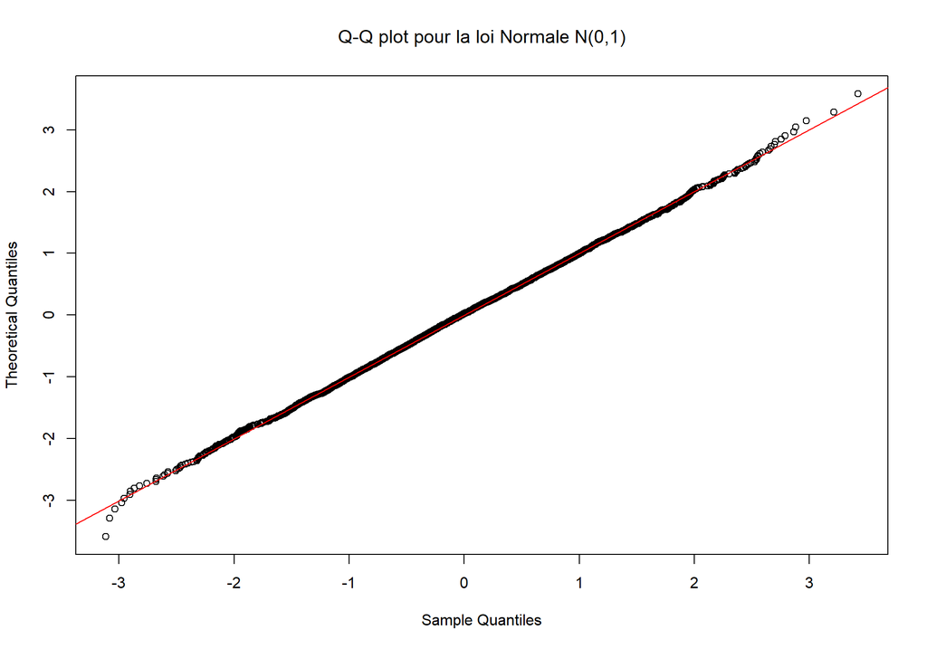

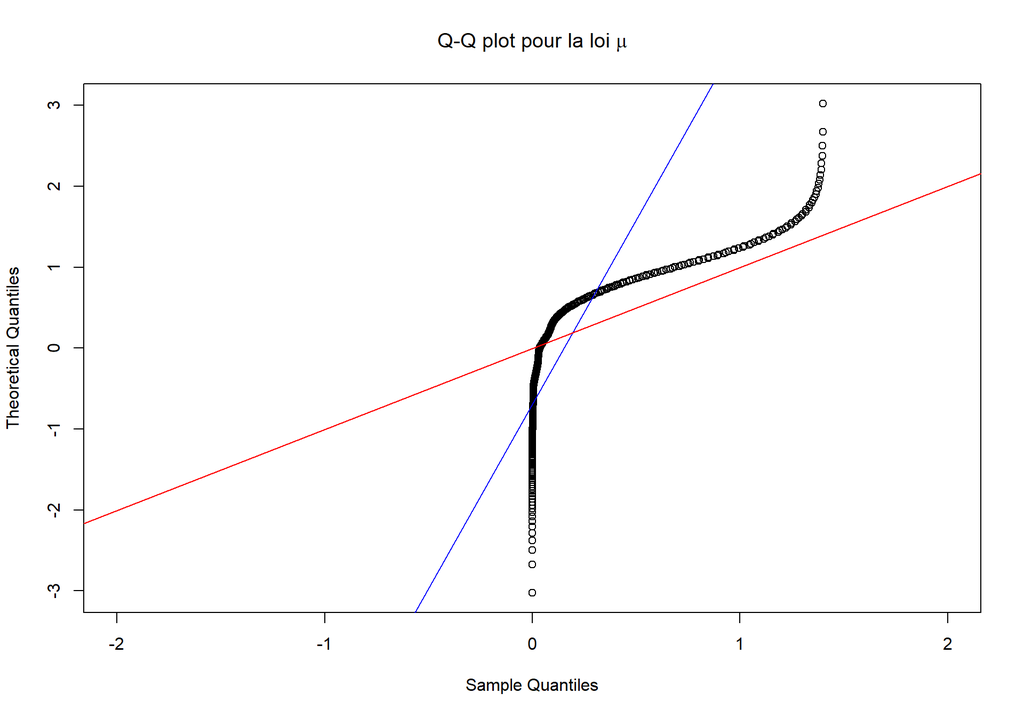

=> non ou bien gaussien par morceau

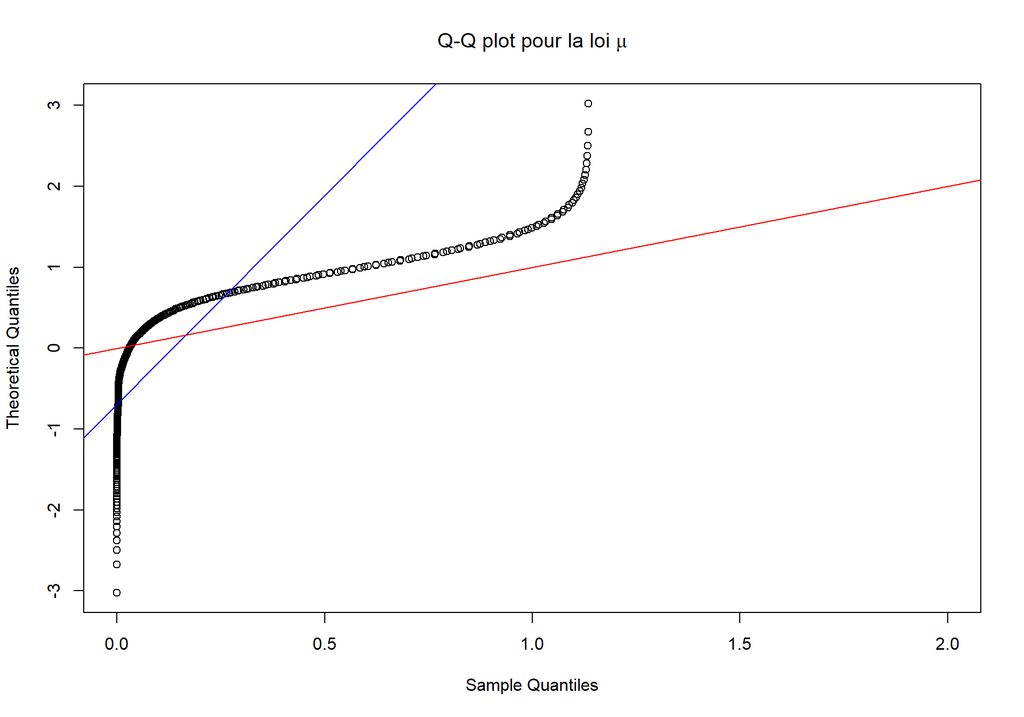

- 2. test de shapiro

```r
 shapiro.test(nu_hcv$y)
```

```
##
##  Shapiro-Wilk normality test
##
## data:  nu_hcv$y
## W = 0.6624, p-value < 2.2e-16
```

```r
 shapiro.test(norm)
```

```
##
##  Shapiro-Wilk normality test
##
## data:  norm
## W = 0.88092, p-value < 2.2e-16
```

Le test de Shapiro-Wilk donne une probabilité de dépassement de p-value < 2.2e-16, nettement < à 0.05. L’hypothèse de normalité est rejettéee.

- 3. test de Kolmogorov-Smirnoff Dans ce cas-ci également, il existe dans R une commande pour tester l’ajustement de données à une loi normale via le test de Kolmogorov-Smirnov:

```r
 ks.test(nu_hcv$y,"pnorm",mean(nu_hcv$y),sd(nu_hcv$y))
```

```
##
##  One-sample Kolmogorov-Smirnov test
##
## data:  nu_hcv$y
## D = 0.28319, p-value < 2.2e-16
## alternative hypothesis: two-sided
```

p-value faible rejetté

#### 3.1.5. homoscedasticité du modèle

(Facultatif.) Comment peut-on tester si le modele est bien homoscedastique ?

### 3.2 A partir du jeu de donnees Data2

On cherche a estimer $\mu$(x) et $\sigma$(x)^2$. Pour cela, on coupe a nouveau l’echantillon en deux et on considere a nouveau ksi(i):

```r
summary(d2)
```

```
##       X.1               X                  Y2
##  Min.   :   1.0   Min.   :0.000005   Min.   :-5.46738
##  1st Qu.: 500.8   1st Qu.:0.258074   1st Qu.: 0.08333
##  Median :1000.5   Median :1.192414   Median : 0.35947
##  Mean   :1000.5   Mean   :2.029447   Mean   : 0.53951
##  3rd Qu.:1500.2   3rd Qu.:3.318174   3rd Qu.: 0.87849
##  Max.   :2000.0   Max.   :9.308684   Max.   :10.15297
```

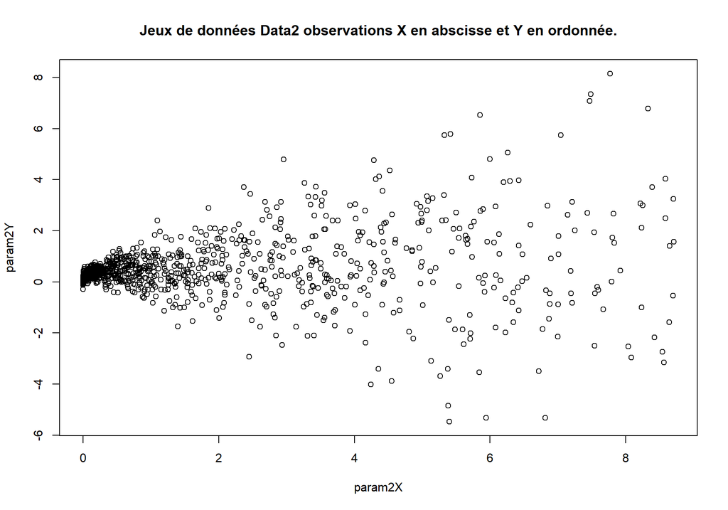

#### 3.2.1. Justifier qu’en regressant $\xi$i sur Xi on obtient un estimateur de $\sigma$(x)^2$.

##### Implémentation et le visualisation graphique

choix de h etabli a la question 2.2: h=0.2186849

```
## [1] 0.01467149
```

```
## [1] 0.11381
```

```
## [1] 0.1200601
```

```
## [1] 0.2186849
```

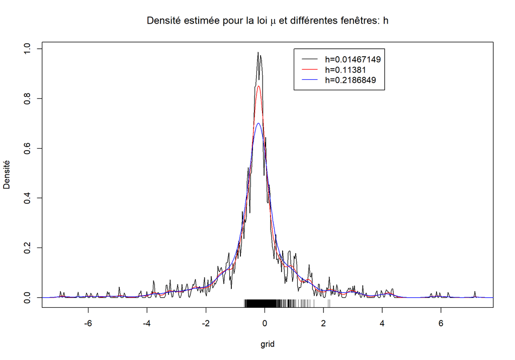

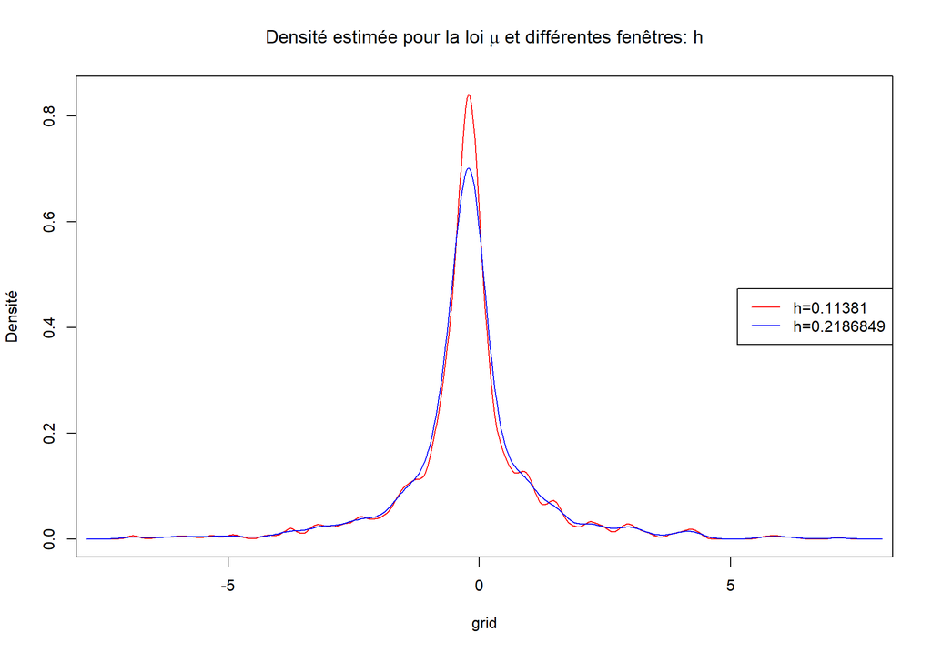

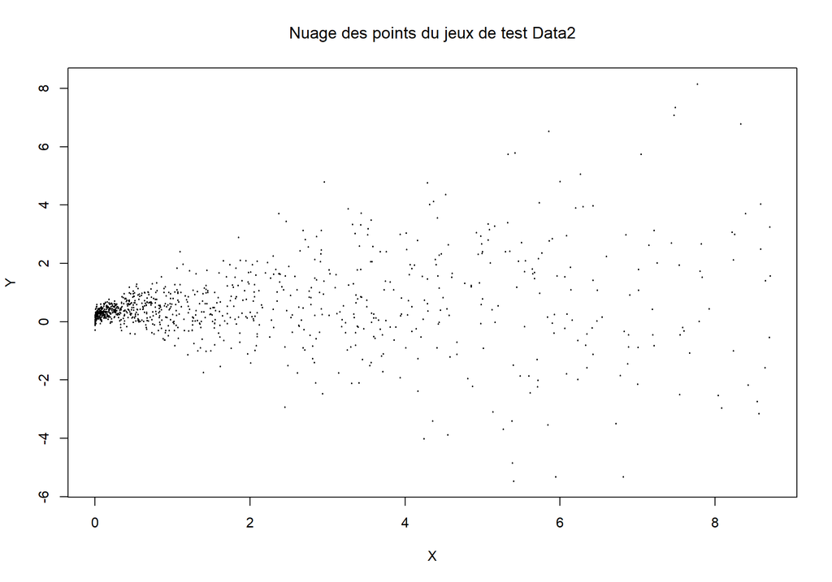

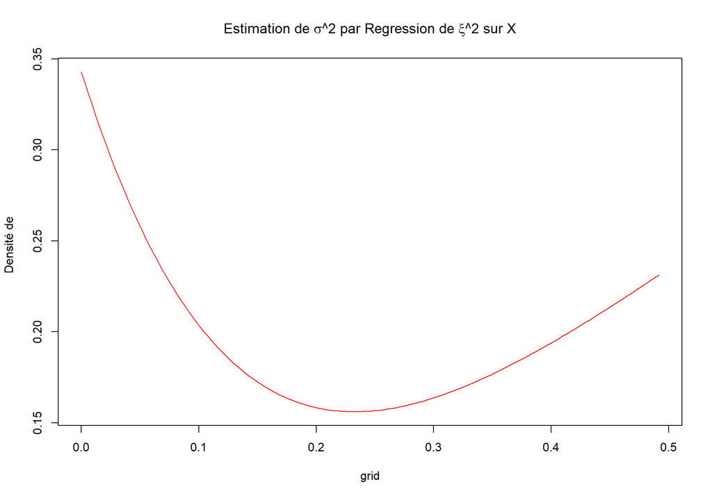

```r
 #hist(fit22$y, breaks=bins32,freq = FALSE,xlab="grid",ylab="Densité", main=expression("Histogramme et estimateurs de "*sigma*"^2"))

 #lines(resH32$x,resH32$y,type="l",col="blue")
 #lines(resHH32$x,resHH32$y,type="l",col="red")
 #legend(6,3,c("h=0.01079333", "h=0.08372629"), col=c("blue", "red"),lty=1:1)
```

=> symétrie, centrée en 0